# act_report

## Analysis Report

### Storing dataset

After cleaning, I proceeded to storing the clean dataset as twitter_archive_master.csv - this cleaned dataset was eventually used in the following analysis.

### Analyzing & Visualization

#### Exploring distribution of rratings

```python
# importing all neccessary dependencies

import pandas as pd
import numpy as np
import matplotlib.pyplot as plt
import seaborn as sb

# reading data from CSV

df = pd.read_csv('twitter_archive_master.csv')
```

```python
# creating a sub_rating

rating_14 = df[(df.rating_numerator <= 14) & (df.rating_numerator.apply(float.is_integer))]

# getting all rating counts of the sub_rating

sub_rating = rating_14.groupby(['rating_numerator']).count()['tweet_id']
sub_rating
```

```
rating_numerator
0.0       2
1.0       5
2.0       9
3.0      19
4.0      16
5.0      33
6.0      32
7.0      52
8.0      98
9.0     154
10.0    436
11.0    417
12.0    489
13.0    295
14.0     40
Name: tweet_id, dtype: int64
```

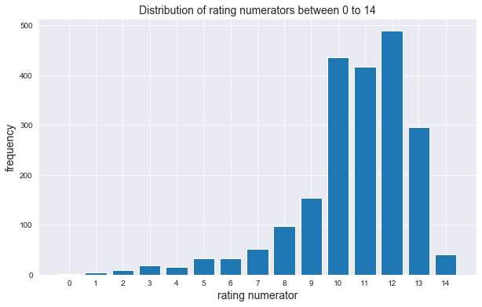

```python
# set the grid style to dark grid
sb.set_style('darkgrid')

# set the size of figures to 10 inches by 6 inches
plt.rcParams['figure.figsize'] = (10, 6)
# set the font size of axis labels to 14
plt.rcParams['axes.labelsize'] = 14
plt.rcParams['axes.titlesize'] = 14

# now we plot another chart

plt.bar(np.arange(15), sub_rating)
plt.xticks(np.arange(15))
plt.xlabel('rating numerator')
plt.ylabel('frequency')
plt.title('Distribution of rating numerators between 0 to 14');
```

#### Insights

We can see in the chart above a distribution of ratungs. The ratings range from 0 to 14 with 14 being the highest. From the distribution above, it is apparent that the most awarded rating was a 12.0 while the least awarded rating was a 0. Also, we notice the range of most awarded ratings was between 10 to 13.

This is bodes quite well for the dogs and we can infer that the dogs are mostly highly-rated on twitter.

### Reference

- Regular expression operations https://docs.python.org/3/library/re.html
- Customize matplotlib using rcParams https://www.youtube.com/watch?v=hJI0wZV7VnA https://matplotlib.org/users/customizing.html
- Set binwidth in matplotlib using numpy.linspace() https://stackoverflow.com/questions/28101623/python-pyplot-histogram-adjusting-bin-width-not-number-of-bins/28101842 https://docs.scipy.org/doc/numpy/reference/generated/numpy.linspace.html
- Plot datetime in scatterplots https://stackoverflow.com/questions/33676608/pandas-type-error-trying-to-plot https://matplotlib.org/api/_as_gen/matplotlib.axes.Axes.plot_date.html
- Set size of plots using plt.figure() https://stackoverflow.com/questions/332289/how-do-you-change-the-size-of-figures-drawn-with-matplotlib
- Convert Tweepy Status Object into JSON https://stackoverflow.com/questions/27900451/convert-tweepy-status-object-into-json
- github.com/help https://github.com/abodacs/Wrangle-and-Analyze-Data-DAND-project/blob/master/wrangle_act.ipynb
- The structure of the Status object of Tweepy https://gist.github.com/dev-techmoe/ef676cdd03ac47ac503e856282077bf2
- Twitter API - get tweets with specific id https://stackoverflow.com/questions/28384588/twitter-api-get-tweets-with-specific-id
- Tweepy documentation http://tweepy.readthedocs.io/en/v3.5.0/index.html
- Reading and Writing JSON to a File in Python http://stackabuse.com/reading-and-writing-json-to-a-file-in-python/
- Clear cell output in a loop https://stackoverflow.com/questions/24816237/ipython-notebook-clear-cell-output-in-code
- Use astype() when NaN is present in pandas series - https://stackoverflow.com/questions/41550746/error-using-astype-when-nan-exists-in-a-dataframe
- Select part of the string in a column https://stackoverflow.com/questions/11350770/pandas-dataframe-select-by-partial-string https://pandas.pydata.org/pandas-docs/stable/generated/pandas.Series.str.contains.html
- Set options https://pandas.pydata.org/pandas-docs/stable/generated/pandas.set_option.html#pandas.set_option
- Set value for one cell https://stackoverflow.com/questions/13842088/set-value-for-particular-cell-in-pandas-dataframe-using-index
- Log transform scales https://matplotlib.org/2.0.1/users/transforms_tutorial.html
- Search for integers in a float column https://stackoverflow.com/questions/49249860/how-to-check-if-float-pandas-column-contains-only-whole-number